# Example 6

# Diel Activity from State-Dependent Animal Movement

#### Author: Brian D. Gerber

#### Date: 2023-09-12

In this example we consider how to use an animal movement behavior analysis to provide inference on diel activity using the $\texttt{Diel.Niche}$ R package. This is by no means the only way to think about animal movement and diel activity. Specifically, we use the R package $\texttt{momentuHMM}$ to fit a hidden Markov model that assumes animal location data are a bivariate time series to estimate step lengths and turning angle’s at each time point. We will consider state-dependent movement, where we estimate the behavioral state (e.g., foraging or traveling) of each location based on step lengths and turning angles. We also consider diel cycles of temperature as a covariate when modeling movement parameters.

# The Setup

```r
# Load packages
  library(Diel.Niche)
  library(lubridate)
  library(suncalc)
  library(momentuHMM)
  library(sf)
  library(ggplot2)
  library(ggpubr)
  library(conicfit)
```

We will use African Elephant (*Loxodonta africana*) data available from Wall et al. 2014 and published online at [MoveBank](http://dx.doi.org/10.5441/001/1.f321pf80).

The animal movement script that fits the hidden Markov model is adapted from the example outlined in $\texttt{momentuHMM}$ and available on GitHub https://github.com/bmcclintock/momentuHMM/blob/master/vignettes/examples/elephantExample.R.

# Movement Data and Iniital Setup

First, we need to load the data and setup the data structure for animal movement modeling.

```r
# We will load data via RData file, but you may also wish to download the data and read it in this way
# CODE NOT RUN
  rawData<- read.csv(
    "Wall et al. 2014 African Elephant Dataset (Source-Save the Elephants).csv"
  )
```

```r
# Select and rename relevant columns
  rawData <- rawData[,
    c(
      "individual.local.identifier",
      "timestamp",
      "location.long",
      "location.lat",
      "external.temperature"
    )
  ]
  colnames(rawData) <- c("ID","time","lon","lat","temp")

# There are two individual's tracks. Only keep the  first track - named, "Salif Keita"
  rawData <- subset(
    rawData,
    ID==unique(ID)[1]
  )

# Convert times from factors to POSIX
  rawData$time <- as.POSIXct(
    rawData$time,
    tz="GMT"
  )


# Project to UTM coordinates using sf
  llcoord <- sf::st_as_sf(
    rawData[,3:4],
    coords = c("lon","lat"),
    crs="+proj=longlat +datum=WGS84"
  )
  utmcoord <- sf::st_transform(
    llcoord,
    crs="+proj=utm +zone=30 ellps=WGS84"
  )

# Add UTM locations to data frame
  rawData$x <-  sf::st_coordinates(utmcoord)[,1]
  rawData$y <-  sf::st_coordinates(utmcoord)[,2]
```

Now with the data all setup, we can standardize the location intervals at hour intervals by using the function `crawlWrap` which implements a continuous-time correlated random walk model.

```r
# Model and Predict locations using crawl - accomadates missing data at one hour intervals
  crwOut <- momentuHMM::crawlWrap(
    rawData,
    timeStep="hour",
    theta=c(6.855, -0.007),
    fixPar=c(NA,NA)
  )
```

Using the output, we can plot the observed and predicted standardized locations.

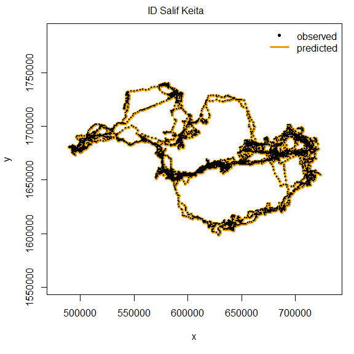

```r
  plot(
    crwOut,
    ask = FALSE
  )
```

# Fitting hidden Markov Models

Now that we have standardized fixed-location intervals, we can estimate state-dependent turning angles and step lengths. First, we will setup our data for model fitting in `momentuHMM`. Overall, we are going to fit three models to these data. The first is a null model (`m1`), the second incorporates some covariates on transition probabilities (`m2`), and the third incorporates covariates onto multiple parameters (`m3`; i.e., transition probabilities, variation in step length, and turning angle concentration).

```r
# Create momentuHMMData object from crwData object
  elephantData <- momentuHMM::prepData(
    data=crwOut,
    covNames="temp"
  )

# Add cosinor covariate based on hour of day
  elephantData$hour <- as.integer(
    strftime(
      elephantData$time,
      format = "%H",
      tz="GMT"
      )
  )

# Label states
  stateNames <- c("encamped","exploratory")

# Distributions for observation processes
  dist = list(step = "gamma", angle = "wrpcauchy")

# Initial parameters
  Par0_m1 <- list(
    step=c(100,500,100,200),
    angle=c(0.3,0.7)
  )
```

The code to fit the null model is…

```r
# Fit hidden markov model with 2 states
  m1 <- momentuHMM::fitHMM(
    data = elephantData,
    nbStates = 2,
    dist = dist,
    Par0 = Par0_m1,
    estAngleMean = list(angle=FALSE),
    stateNames = stateNames
  )
```

Next, let’s consider a model (`m2`) where the transition probabilities between states vary by temperature and the interaction with a cyclical function based on the hour of the day. See https://cran.r-project.org/web/packages/momentuHMM/vignettes/momentuHMM.pdf for more details.

```r
# Formula for transition probabilities
  formula <- ~ temp * cosinor(hour, period = 24)

# Initial parameters (obtained from nested model m1)
  Par0_m2 <- momentuHMM::getPar0(
    model=m1,
    formula=formula
  )

  # And fit the model
  m2 <- momentuHMM::fitHMM(
    data = elephantData,
    nbStates = 2,
    dist = dist,
    Par0 = Par0_m2$Par,
    beta0=Par0_m2$beta,
    stateNames = stateNames,
    formula=formula
  )
```

Lastly, we will consider a more complex model (m3) where the transition probabilities and mean and standard deviation of step lengths vary by the cyclicality of temperature, and the concentration of the turning angle varies by temperature. See https://cran.r-project.org/web/packages/momentuHMM/vignettes/momentuHMM.pdf for more details on using cyclical or spline functions to model complex non-linear variation.

```r
# Formulas for parameters of state-dependent observation distributions
  DM <- list(
    step = list(
      mean = ~ temp * cosinor(hour, period = 24),
      sd = ~ temp * cosinor(hour, period = 24)
    ),
    angle = list(
      concentration = ~ temp
    )
  )

# Initial parameters (obtained from nested model m2)
  Par0_m3 <- momentuHMM::getPar0(
    model=m2,
    formula=formula, DM=DM
  )

# And fit the model
  m3 <- momentuHMM::fitHMM(
    data = elephantData,
    nbStates = 2,
    dist = dist,
    Par0 = Par0_m3$Par,
    beta0 = Par0_m3$beta,
    DM = DM,
    stateNames = stateNames,
    formula = formula
  )
```

We can compare the three models using Akaike’s Information Criterion (AIC).

```r
# Calculate and compare AIC
  aic_table <- AIC(m1,m2,m3)
# calculate delta AIC
  aic_table$deltaAIC <- round(aic_table$AIC - min(aic_table$AIC),2)
  aic_table[order(aic_table$deltaAIC),]
```

```
#>   Model      AIC deltaAIC
#> 1    m3 381322.3     0.00
#> 2    m2 382079.3   757.00
#> 3    m1 382589.9  1267.62
```

Using AIC as an estimate of the Expected Kullback-Leibler discrepancy, we see that the most complex model, model 3, is the most supported. This is because it is has the lowest AIC value, which means it is the model with the minimum difference from the theoretical generating model, relative to the other two models in the model set.

```r
# Show model parameters, but clean them up a bit so it's easier to read

m3_results <- list(
  step_coefs = data.frame(
    parameter = colnames(m3$mle$step),
    estimate = round(as.numeric(m3$mle$step),2)
  ),
  step_params = data.frame(
    state = c("encamped", "exploratory"),
    mean = m3$CIreal$step$est["mean",],
    sd = m3$CIreal$step$est["sd",]
  ),
  angle_coefs = data.frame(
    parameter = colnames(m3$mle$angle),
    estimate = round(as.numeric(m3$mle$angle),2)
  ),
  angle_params = data.frame(
    state = c("encamped", "exploratory"),
    concentration = as.numeric(unname(m3$CIreal$angle$est))
  ),
  transition_coefs =  round(m3$mle$beta,2),
  transition_matrix = round(m3$CIreal$gamma$est,2),
  initial_distribution = round(m3$mle$delta,2)
)

m3_results
```

```
#> $step_coefs
#>                                    parameter estimate
#> 1                         mean_1:(Intercept)     5.47
#> 2                                mean_1:temp     0.00
#> 3       mean_1:cosinorCos(hour, period = 24)    -0.72
#> 4       mean_1:cosinorSin(hour, period = 24)    -0.48
#> 5  mean_1:temp:cosinorCos(hour, period = 24)     0.03
#> 6  mean_1:temp:cosinorSin(hour, period = 24)     0.01
#> 7                         mean_2:(Intercept)     6.84
#> 8                                mean_2:temp     0.01
#> 9       mean_2:cosinorCos(hour, period = 24)     0.04
#> 10      mean_2:cosinorSin(hour, period = 24)     0.10
#> 11 mean_2:temp:cosinorCos(hour, period = 24)     0.01
#> 12 mean_2:temp:cosinorSin(hour, period = 24)    -0.01
#> 13                          sd_1:(Intercept)     5.33
#> 14                                 sd_1:temp     0.01
#> 15        sd_1:cosinorCos(hour, period = 24)    -0.25
#> 16        sd_1:cosinorSin(hour, period = 24)    -0.65
#> 17   sd_1:temp:cosinorCos(hour, period = 24)     0.02
#> 18   sd_1:temp:cosinorSin(hour, period = 24)     0.02
#> 19                          sd_2:(Intercept)     6.61
#> 20                                 sd_2:temp     0.00
#> 21        sd_2:cosinorCos(hour, period = 24)    -0.07
#> 22        sd_2:cosinorSin(hour, period = 24)     0.09
#> 23   sd_2:temp:cosinorCos(hour, period = 24)     0.01
#> 24   sd_2:temp:cosinorSin(hour, period = 24)     0.00
#>
#> $step_params
#>                   state     mean       sd
#> encamped       encamped 185.3877 172.8976
#> exploratory exploratory 865.6211 620.8493
#>
#> $angle_coefs
#>                     parameter estimate
#> 1 concentration_1:(Intercept)    -0.32
#> 2        concentration_1:temp    -0.02
#> 3 concentration_2:(Intercept)     0.88
#> 4        concentration_2:temp    -0.01
#>
#> $angle_params
#>         state concentration
#> 1    encamped     0.3115387
#> 2 exploratory     0.6611815
#>
#> $transition_coefs
#>                                    1 -> 2 2 -> 1
#> (Intercept)                         -1.83  -0.81
#> temp                                -0.02  -0.02
#> cosinorCos(hour, period = 24)       -1.85   0.50
#> cosinorSin(hour, period = 24)        0.51   0.25
#> temp:cosinorCos(hour, period = 24)   0.05  -0.04
#> temp:cosinorSin(hour, period = 24)  -0.02   0.00
#>
#> $transition_matrix
#>             encamped exploratory
#> encamped        0.88        0.12
#> exploratory     0.30        0.70
#>
#> $initial_distribution
#>                encamped exploratory
#> ID:Salif Keita     0.53        0.47
```

There are a lot of results to consider from this model. We encourage those interested to follow up with the https://cran.r-project.org/web/packages/momentuHMM/vignettes/momentuHMM.pdf. However, notice that the mean step-lengths are much different between the `encamped` (185 m) and `exploratory` (866 m) movement states. Further, looking at the transition probabilities between states tells us that when this individual is moving according to either of the two behavioral states, they are more likely to stay in the same state between 1 hour location intervals (at mean covariate values).

Now lets plot the covariate effects and movement track along with the estimated movement states.

```
#> Decoding state sequence... DONE
```

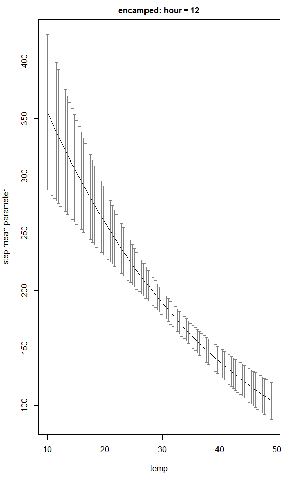

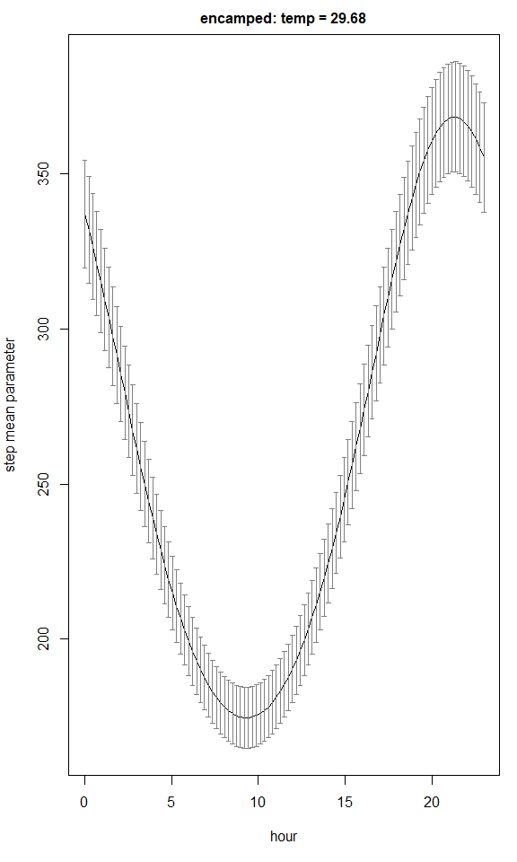

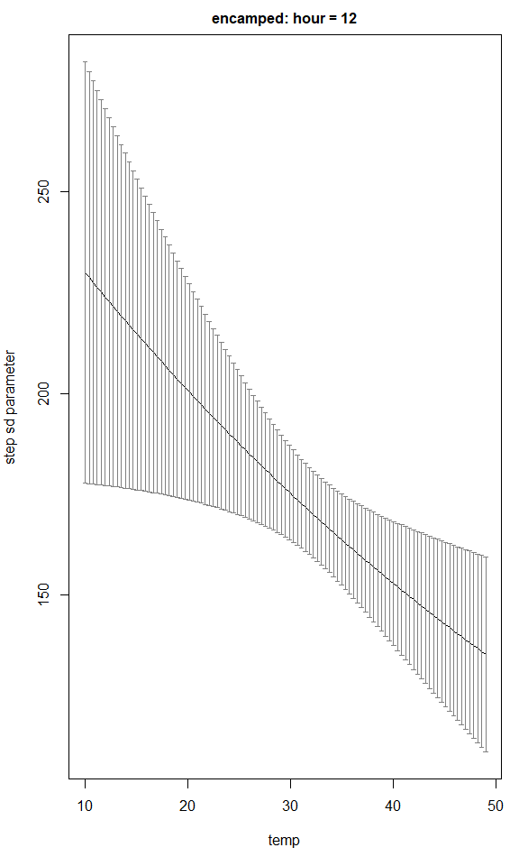

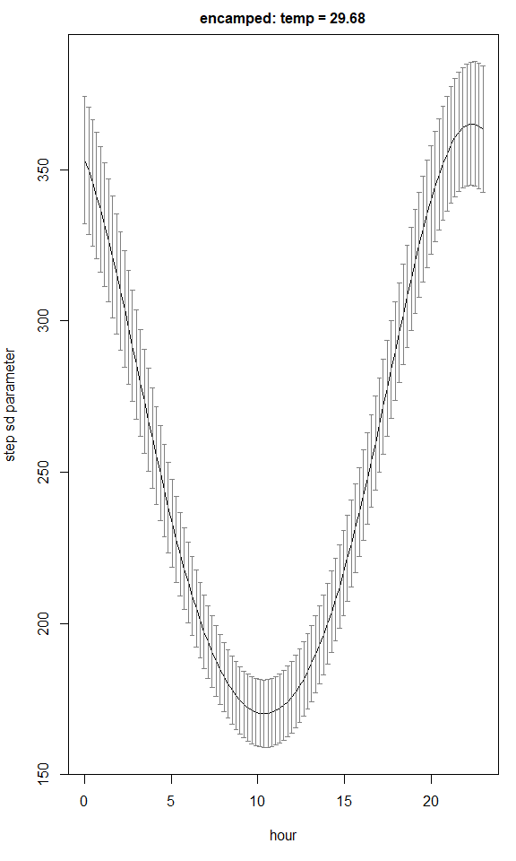

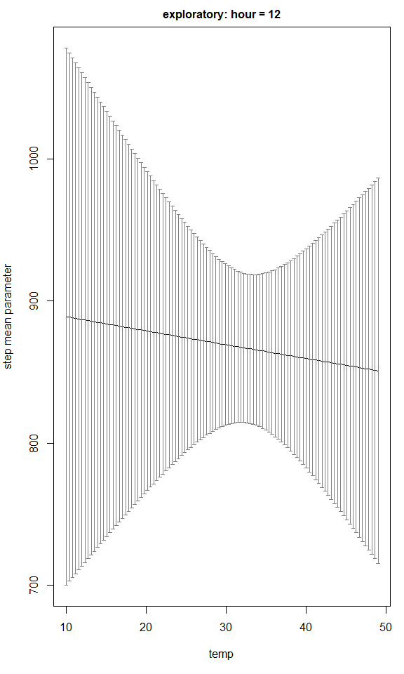

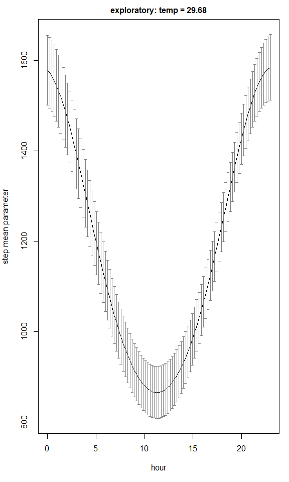

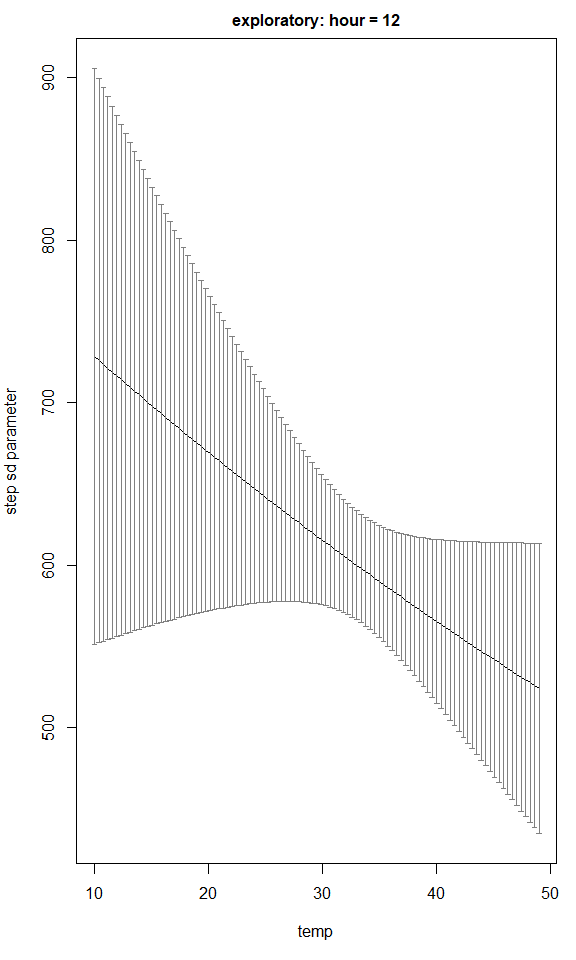

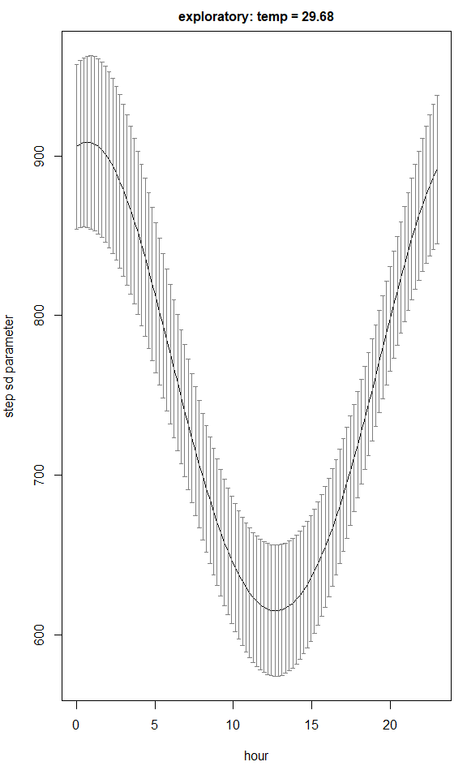

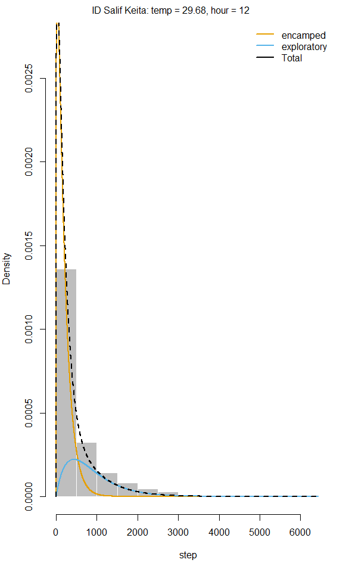

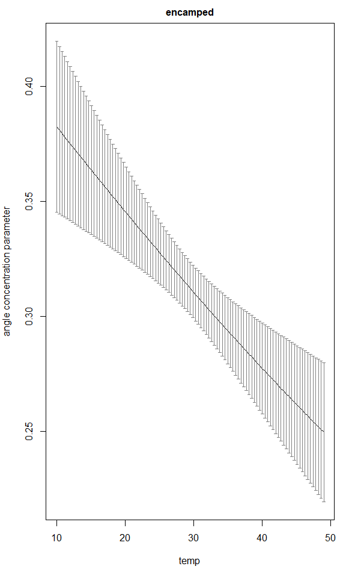

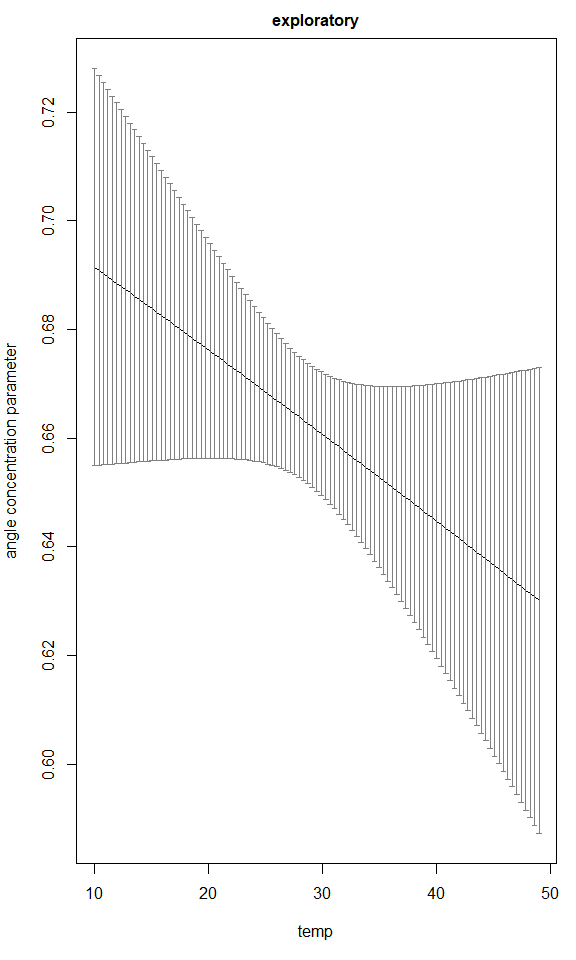

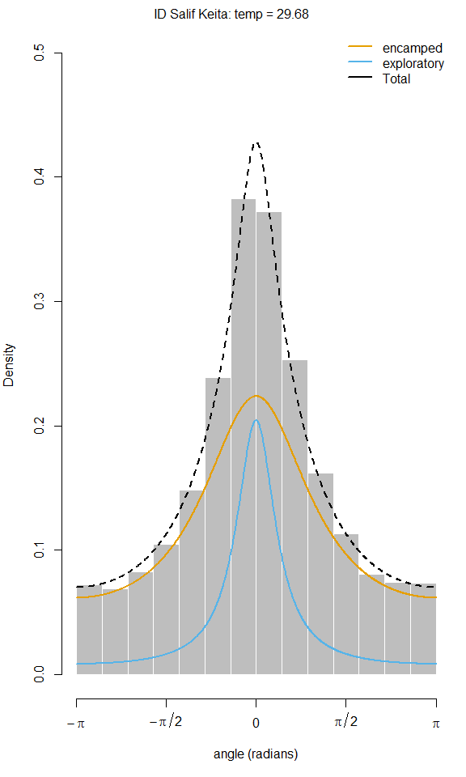

[3 more figures not shown]

```r
  plot(m3, plotCI = TRUE, covs = data.frame(hour=12))
```